# Homework 1

Ayberk AKGÜN

18/10/2019

For the tasks, I will mainly use tidyverse, data.table and ggplot2 libraries.

```r
library(tidyverse)
library(data.table)
library(tidyr)
library(ggplot2)
```

# Task 1

For task 1 I use “matches” data which can be found on https://drive.google.com/drive/u/4/folders/1SkhJNE3ckir74oPMXTP7T3hUD5ZdB501. I read the match results from directory and filter only the English Premier League games which have the id of “148”.

```r
matches<-read.csv("/Users/ayberkakgun/Desktop/bets/matches.csv")
matches_premier<- matches %>%
  filter(league_id==148 & match_status=="Finished") %>%
  as.data.table()
```

### 1. Drawing Histograms

I plot the histogram of hometeam score with hist function and arrange the axes:

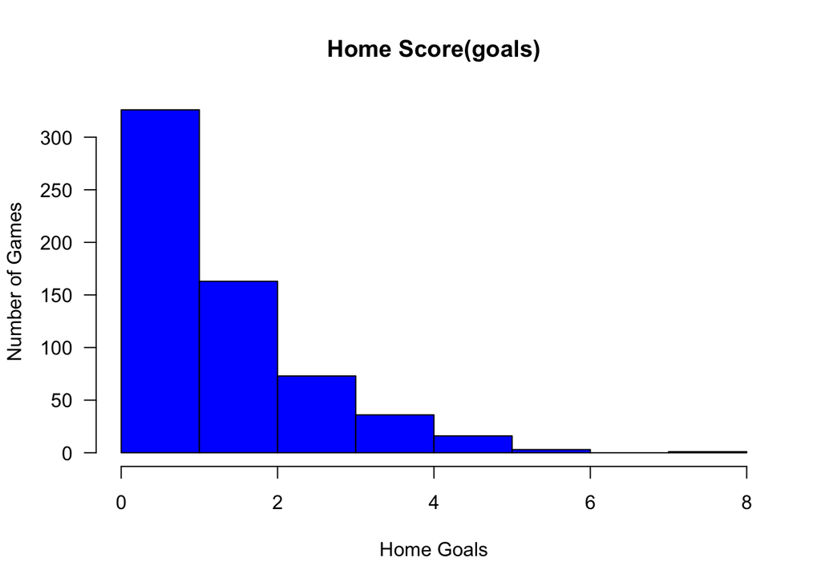

```r
hist(matches_premier$match_hometeam_score,
     main="Home Score(goals)",
     xlab="Home Goals",
     ylab="Number of Games",
     # xlim=c(-1,7),
     col="blue",
     las=1,
     breaks=8)
```

With the same method, histogram of away score:

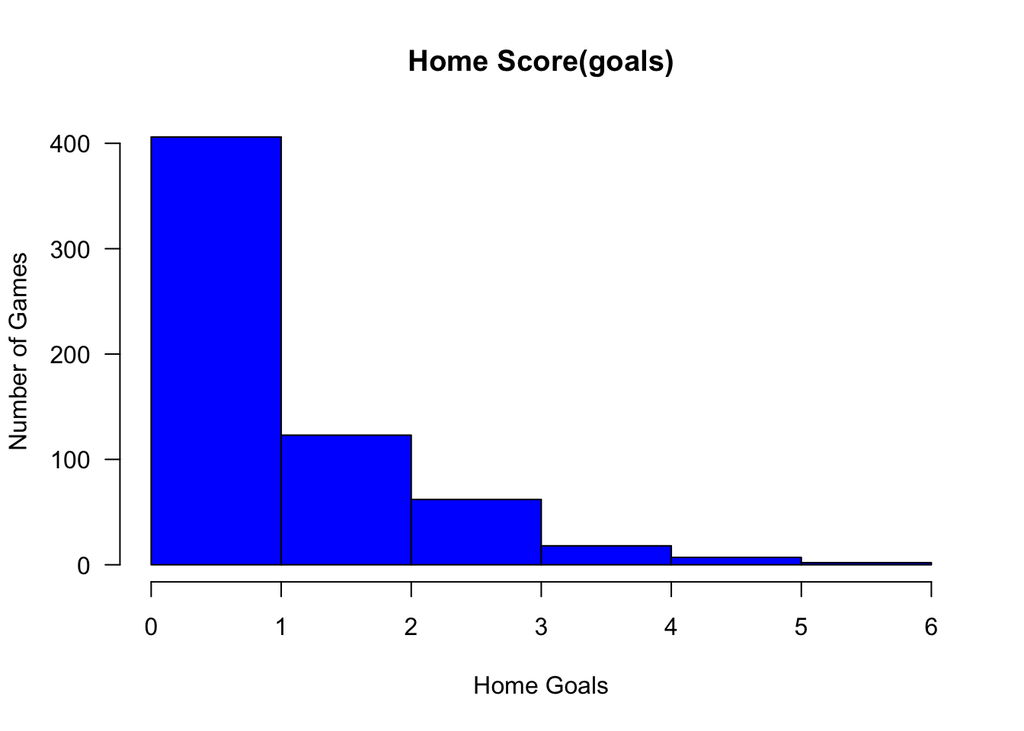

```r
hist(matches_premier$match_awayteam_score,
     main="Home Score(goals)",
     xlab="Home Goals",
     ylab="Number of Games",
     border="black",
     # xlim=c(min,max),
     col="blue",
     las=1,
     breaks=8)
```

and the histogram of home - away score:

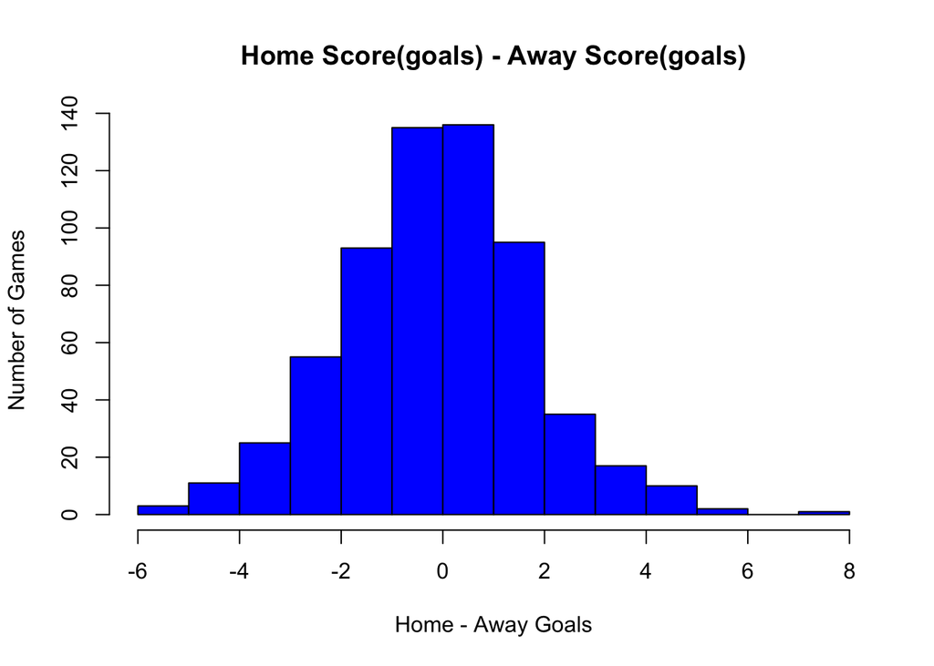

```r
hist(matches_premier$match_hometeam_score-matches_premier$match_awayteam_score,
     main="Home Score(goals) - Away Score(goals)",
     xlab="Home - Away Goals",
     ylab="Number of Games",
     # xlim=c(min,max),
     # ylim=c(0,max(ypois_homeaway)),
     col="blue")
```

I calculate expected number of games for each goal number, using the sample mean as the distribution mean in the interval between min and max. Then i draw the line on histogram:

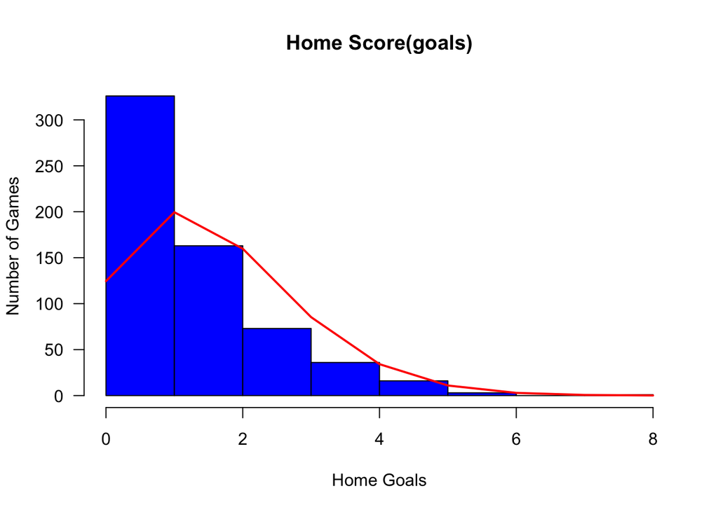

```r
mean_home<-mean(matches_premier$match_hometeam_score,na.rm = TRUE)
count_home<-na.omit(matches_premier$match_hometeam_score) %>% length()
min<-na.omit(matches_premier$match_hometeam_score) %>% min()
max<-na.omit(matches_premier$match_hometeam_score) %>% max()
ypois_home<-dpois(min:max,mean_home)*count_home
hist(matches_premier$match_hometeam_score,
     main="Home Score(goals)",
     xlab="Home Goals",
     ylab="Number of Games",
     # xlim=c(-1,7),
     col="blue",
     las=1,
     breaks=8)
lines(x=min:max,y=ypois_home,col="red",lwd=2)
```

I follow the same procedure for away goals:

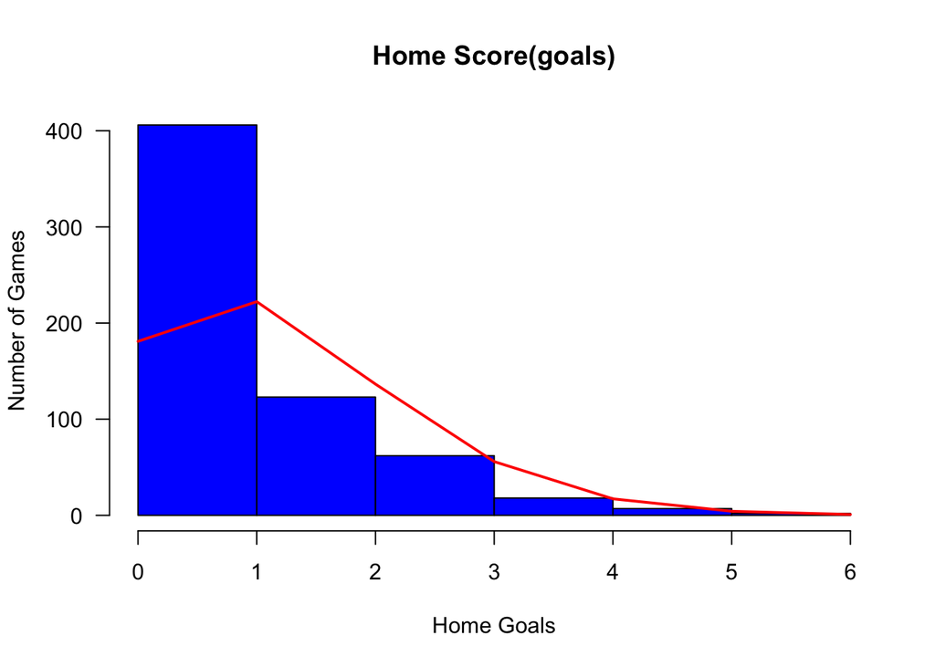

```r
mean_away<-mean(matches_premier$match_awayteam_score,na.rm = TRUE)
count_away<-na.omit(matches_premier$match_awayteam_score) %>% length()
min<-
  na.omit(matches_premier$match_awayteam_score) %>% min()
max<-na.omit(matches_premier$match_awayteam_score) %>% max()
ypois_away<-dpois(min:max,mean_away)*count_away
hist(matches_premier$match_awayteam_score,
     main="Home Score(goals)",
     xlab="Home Goals",
     ylab="Number of Games",
     border="black",
     # xlim=c(min,max),
     col="blue",
     las=1,
     breaks=8)
lines(x=min:max,y=ypois_away,col="red",lwd=2)
```

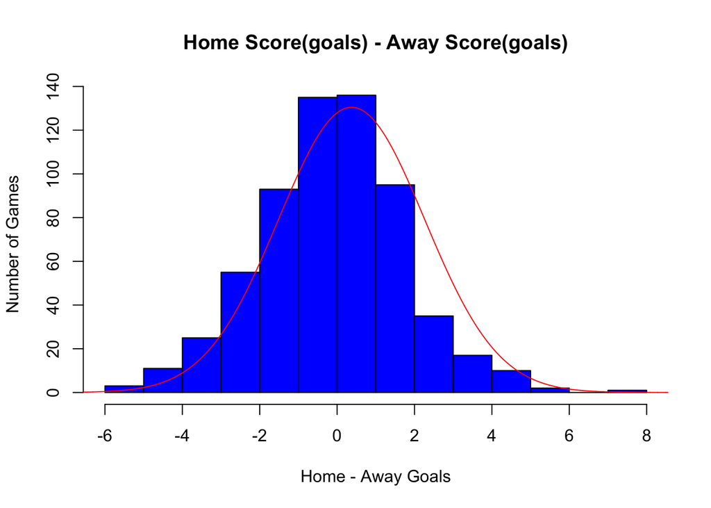

```r
mean_homeaway<-na.omit(matches_premier$match_hometeam_score-matches_premier$match_awayteam_score) %>% mean(.,na.rm = TRUE)
std_homeaway<-sd(na.omit(matches_premier$match_hometeam_score-matches_premier$match_awayteam_score))
count_homeaway<-na.omit(matches_premier$match_awayteam_score--matches_premier$match_awayteam_score) %>% length()
min<-
  na.omit(matches_premier$match_hometeam_score-matches_premier$match_awayteam_score) %>% min()
x <- seq(-10, 10, length=10000)
y <- dnorm(x, mean=mean_homeaway, sd=std_homeaway)*count_homeaway
max<-na.omit(matches_premier$match_hometeam_score-matches_premier$match_awayteam_score) %>% max()
ypois_homeaway<-dnorm(min:max,mean_homeaway)*count_homeaway
hist(matches_premier$match_hometeam_score-matches_premier$match_awayteam_score,
     main="Home Score(goals) - Away Score(goals)",
     xlab="Home - Away Goals",
     ylab="Number of Games",
     # xlim=c(min,max),
     # ylim=c(0,max(ypois_homeaway)),
     col="blue")
lines(x,y,col="red")
```

# Task 2

```r
bets<-as.data.table(read.csv("/Users/ayberkakgun/Desktop/bets/bets.csv")) %>%
filter(odd_bookmakers=="Marsbet" | odd_bookmakers=="Leonbets" |
         odd_bookmakers=="5Dimes" | odd_bookmakers=="Betclic" | odd_bookmakers=="NordicBet")
head(bets)
```

```
##   match_id odd_bookmakers  odd_epoch variable value
## 1   151780         5Dimes 1486314920    odd_1  2.23
## 2   151781         5Dimes 1486314941    odd_1  2.99
## 3   151780         5Dimes 1486314920    odd_x  3.19
## 4   151781         5Dimes 1486314941    odd_x  3.48
## 5   151780         5Dimes 1486314920    odd_2  3.82
## 6   151781         5Dimes 1486314941    odd_2  2.52
```

I filter for home win, draw and away win odds; cahnge from long to wide by combining odds of a game into one line with spread function.

```r
bets_long <- bets %>%
  filter(variable=="odd_1" | variable=="odd_x" | variable=="odd_2") %>%
  spread(variable, value) %>%
  as.data.table()
head(bets_long)
```

```
##    match_id odd_bookmakers  odd_epoch odd_1 odd_2 odd_x
## 1:   145899        Betclic 1489305781  6.50  1.38  4.30
## 2:   145900        Betclic 1489305801  2.05  2.80  3.60
## 3:   147990         5Dimes 1486710451  2.16  3.94  3.31
## 4:   147991         5Dimes 1486797015  1.94  4.48  3.54
## 5:   147992         5Dimes 1486797022  8.89  1.41  5.06
## 6:   147993         5Dimes 1486797032  9.21  1.43  4.75
```

## 1.

I calculate probabilities as 1/odds and add them as new cells, (with a little practice of data.table)

```r
bets_long[,p1:=1/odd_1]
bets_long[,p0:=1/odd_x]
bets_long[,p2:=1/odd_2]
```

## 2.

Then I normalize,

```r
bets_long[,psum:=p1+p2+p0]
bets_long[,p11:=p1/psum]
bets_long[,p00:=p0/psum]
bets_long[,p22:=p2/psum]
bets_long[,p12:=p11-p22]
```

Let’s check the plot of P(home win) – P(away win) on x-axis and P (tie) on y axis, both calculated from bet odds.

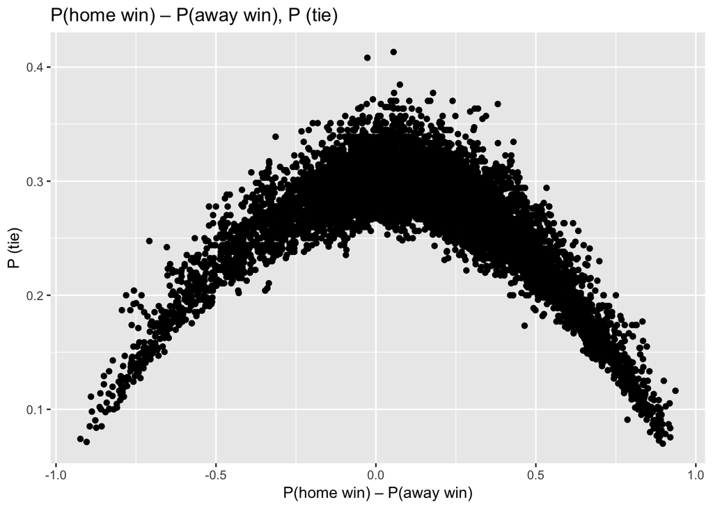

```r
ggplot(bets_long)+aes(x=p1-p2,y=p0)+geom_point()+xlab("P(home win) – P(away win)")+ylab("P (tie)")+ggtitle("P(home win) – P(away win), P (tie)")
```

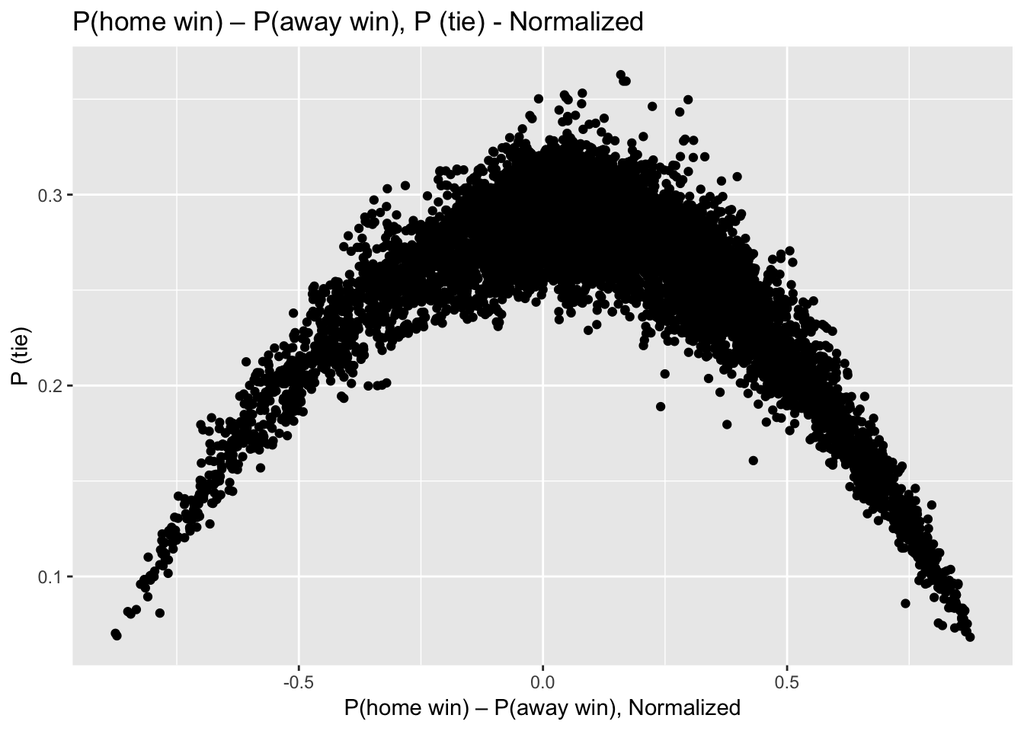

```r
ggplot(bets_long)+aes(x=p11-p22,y=p00)+geom_point()+xlab("P(home win) – P(away win), Normalized")+ylab("P (tie)")+ggtitle("P(home win) – P(away win), P (tie) - Normalized")
```

## 2.

Then comes the tricky part. Let’s construct bins for P(home) - P(away) with 0.2 intervals.

```r
matches_premier[,matchresult:=match_hometeam_score-match_awayteam_score]

bets_short<-bets_long %>%
  select(odd_bookmakers, match_id, p12, p0) %>%
       mutate(bin = case_when(p12 <= 1 & p12 > 0.8 ~ 1,
                            p12 <= 0.8 & p12 > 0.6 ~ 2,
                            p12 <= 0.6 & p12 > 0.4 ~ 3,
                            p12 <= 0.4 & p12 > 0.2 ~ 4,
                            p12 <= 0.2 & p12 > 0 ~ 5,
                            p12 <= 0 & p12 > -0.2 ~ 6,
                            p12 <= -0.2 & p12 > -0.4 ~ 7,
                            p12 <= -0.4 & p12 > -0.6 ~ 8,
                            p12 <= -0.6 & p12 > -0.8 ~ 9,
                            p12 <= -0.8 & p12 > -1 ~ 10,
                             TRUE ~ 0))
```

```r
comparison<-matches_premier %>%
  select(match_id,matchresult) %>%
  right_join(bets_short,by="match_id")

bin_count<-comparison %>%
  filter(matchresult==1|matchresult==0|matchresult==2) %>%
  group_by(odd_bookmakers,bin) %>%
  count()

bin_result<-comparison %>%
  filter(matchresult==0) %>%
  group_by(odd_bookmakers,bin) %>%
  count() %>%
  ungroup() %>%
  right_join(bin_count,by=c("bin","odd_bookmakers"))  %>%
  mutate(prob=n.x/n.y) %>%
  select(odd_bookmakers,prob,bin)

  graph<-bets_short %>%
  right_join(bin_result,by=c("bin","odd_bookmakers"))
```

Then the only thing left is to put on graph. P(home) - P(away) on x axis and sample probabilities on y axis, for each bookmaker.

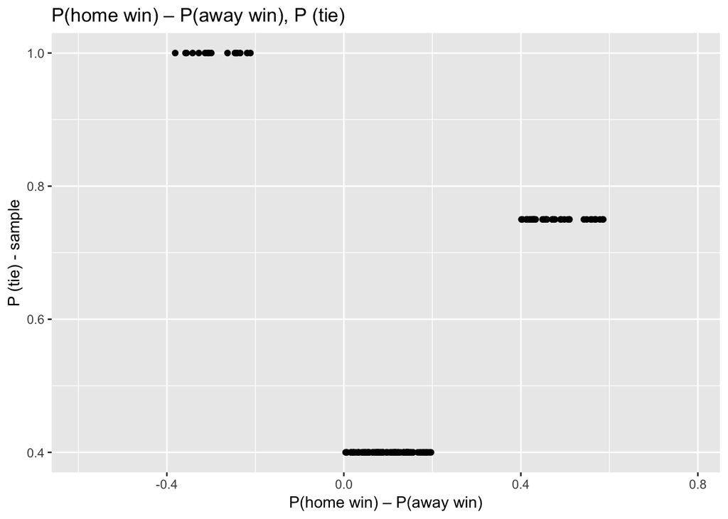

```r
  filter(graph, odd_bookmakers=="Marsbet") %>%
  ggplot()+aes(x=p12,y=prob)+geom_point()+xlab("P(home win) – P(away win)")+ylab("P (tie) - sample")+ggtitle("P(home win) – P(away win), P (tie)")
```

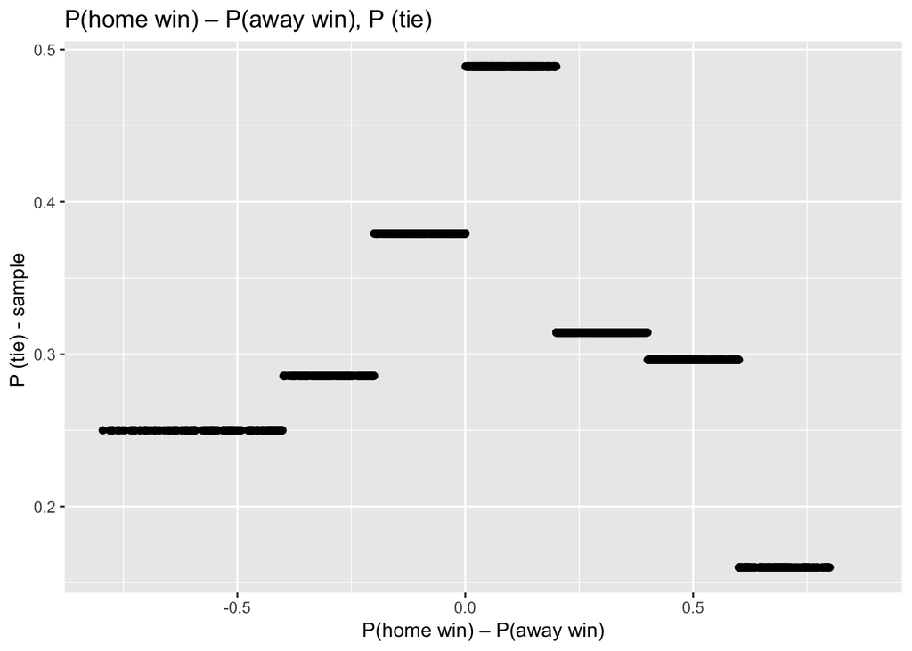

```r
  filter(graph, odd_bookmakers=="Leonbets") %>%
  ggplot()+aes(x=p12,y=prob)+geom_point()+xlab("P(home win) – P(away win)")+ylab("P (tie) - sample ")+ggtitle("P(home win) – P(away win), P (tie)")
```

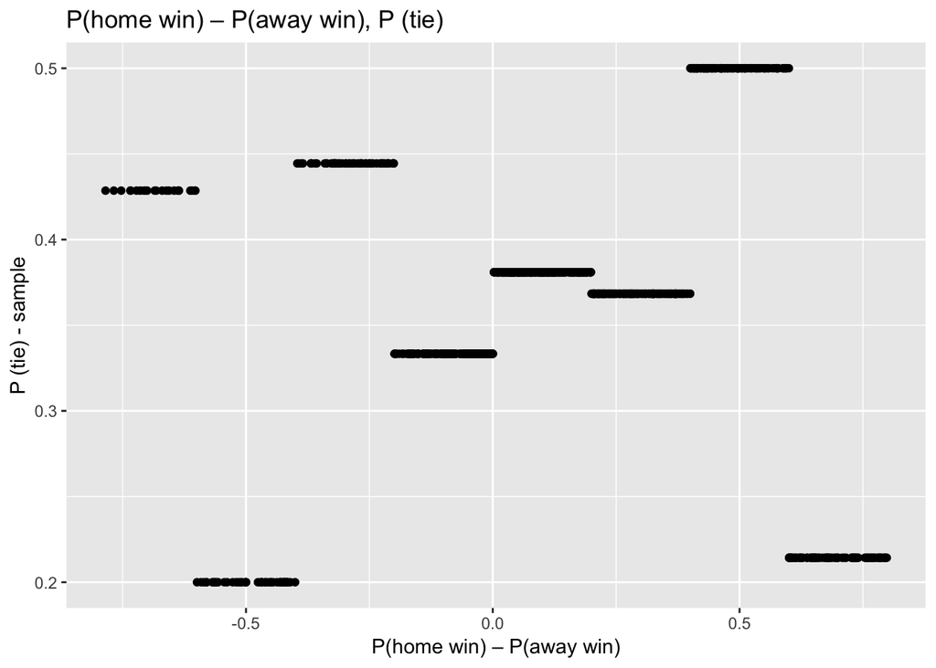

```r
  filter(graph, odd_bookmakers=="5Dimes") %>%
  ggplot()+aes(x=p12,y=prob)+geom_point()+xlab("P(home win) – P(away win)")+ylab("P (tie) - sample")+ggtitle("P(home win) – P(away win), P (tie)")
```

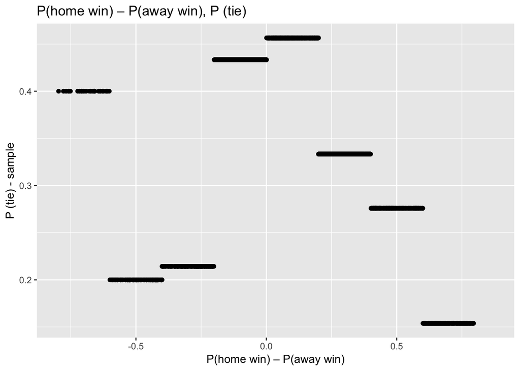

```r
  filter(graph, odd_bookmakers=="Betclic") %>%
  ggplot()+aes(x=p12,y=prob)+geom_point()+xlab("P(home win) – P(away win)")+ylab("P (tie) - sample")+ggtitle("P(home win) – P(away win), P (tie)")
```

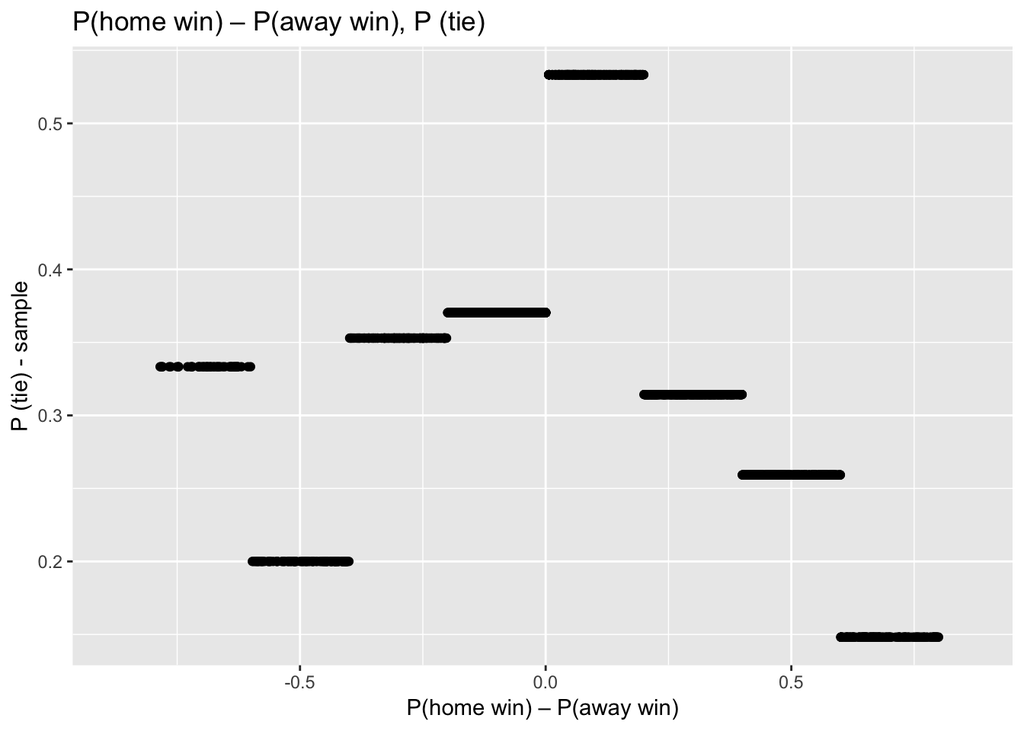

```r
  filter(graph, odd_bookmakers=="NordicBet") %>%
  ggplot()+aes(x=p12,y=prob)+geom_point()+xlab("P(home win) – P(away win)")+ylab("P (tie) - sample")+ggtitle("P(home win) – P(away win), P (tie)")
```

# Task 3

I use booking data to find games, where happened a red card in the first 15 minutes. Number of excluded matches are for red card is as follows:

```r
booking<-read.csv("/Users/ayberkakgun/Desktop/bets/booking.csv") %>%
  filter(card=="red card" & as.numeric(as.character(time))<=15) %>%
  select(match_id)

summary(matches_premier$match_id %in% booking$match_id==TRUE)
```

```
##    Mode   FALSE    TRUE
## logical     614       4
```

Then I combine it with the games where an extra time goal affected the score. Be careful an extra score that didn’t change the result shouldn’t be removed. Remaining matches are the “clean matches”. Number of excluded matches in total:

```r
# matches2<-read.csv("/Users/ayberkakgun/Desktop/bets/matches.csv") %>% filter(league_id==148) %>%
#   as.data.table()
# matches_premier[,matchresult:=match_hometeam_score-match_awayteam_score]
matches_premier[,matchresult2:=match_hometeam_score+match_hometeam_extra_score-match_awayteam_score-match_awayteam_extra_score]
    question_matches<-matches_premier %>%
  filter(matchresult!=matchresult2 & matchresult==0 | matchresult2==0) %>%
      select(match_id) %>%
    union(booking)

    clean_matches<-matches_premier %>%
      filter(!(matches_premier$match_id %in% question_matches$match_id)) %>%
      as.data.table()

    summary(matches_premier$match_id %in% question_matches$match_id==TRUE)
```

```
##    Mode   FALSE    TRUE
## logical     467     151
```

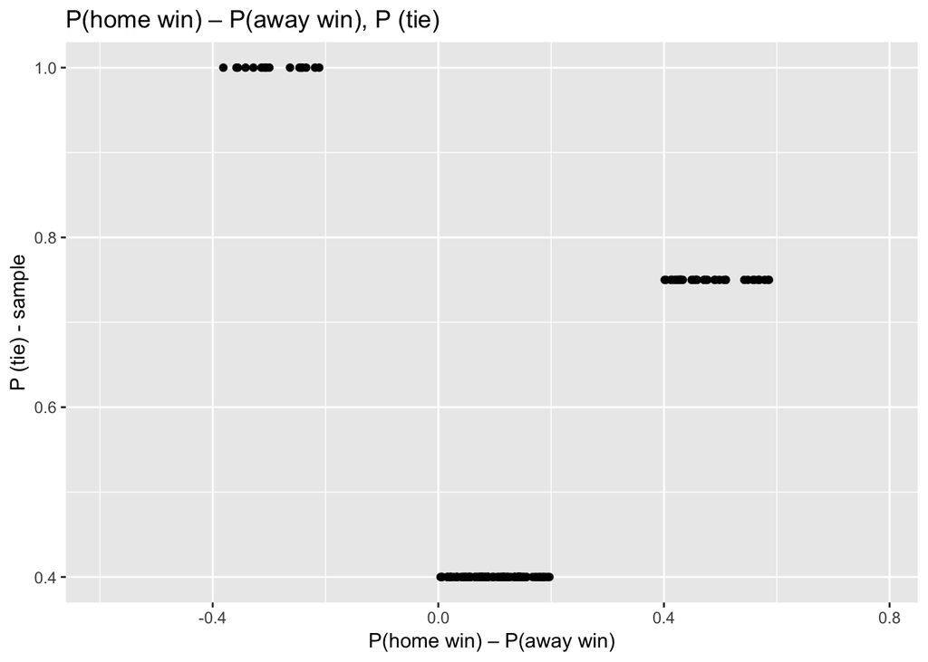

```r
comparison2<-clean_matches %>%
  select(match_id,matchresult) %>%
  right_join(bets_short,by="match_id")

bin_count<-comparison %>%
  filter(matchresult==1|matchresult==0|matchresult==2) %>%
  group_by(odd_bookmakers,bin) %>%
  count()
bin_result<-comparison %>%
  filter(matchresult==0) %>%
  group_by(odd_bookmakers,bin) %>%
  count() %>%
  ungroup() %>%
  right_join(bin_count,by=c("bin","odd_bookmakers"))  %>%
  mutate(prob=n.x/n.y) %>%
  select(odd_bookmakers,prob,bin)

  graph<-bets_short %>%
  right_join(bin_result,by=c("bin","odd_bookmakers"))

  filter(graph, odd_bookmakers=="Marsbet") %>%
  ggplot()+aes(x=p12,y=prob)+geom_point()+xlab("P(home win) – P(away win)")+ylab("P (tie) - sample")+ggtitle("P(home win) – P(away win), P (tie)")
```

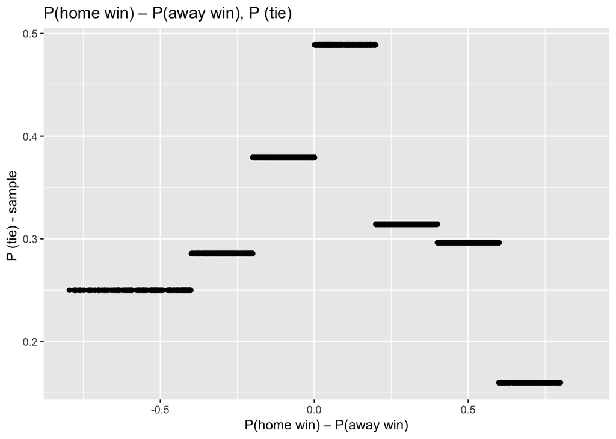

```r
  filter(graph, odd_bookmakers=="Leonbets") %>%
  ggplot()+aes(x=p12,y=prob)+geom_point()+xlab("P(home win) – P(away win)")+ylab("P (tie) - sample ")+ggtitle("P(home win) – P(away win), P (tie)")
```

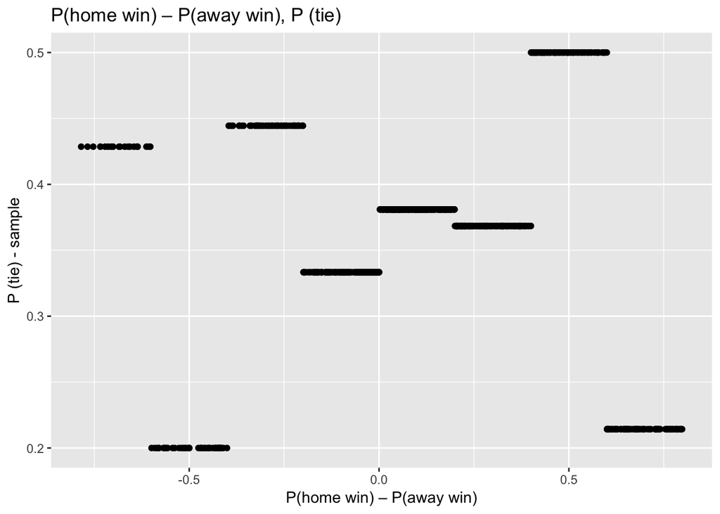

```r
  filter(graph, odd_bookmakers=="5Dimes") %>%
  ggplot()+aes(x=p12,y=prob)+geom_point()+xlab("P(home win) – P(away win)")+ylab("P (tie) - sample")+ggtitle("P(home win) – P(away win), P (tie)")
```

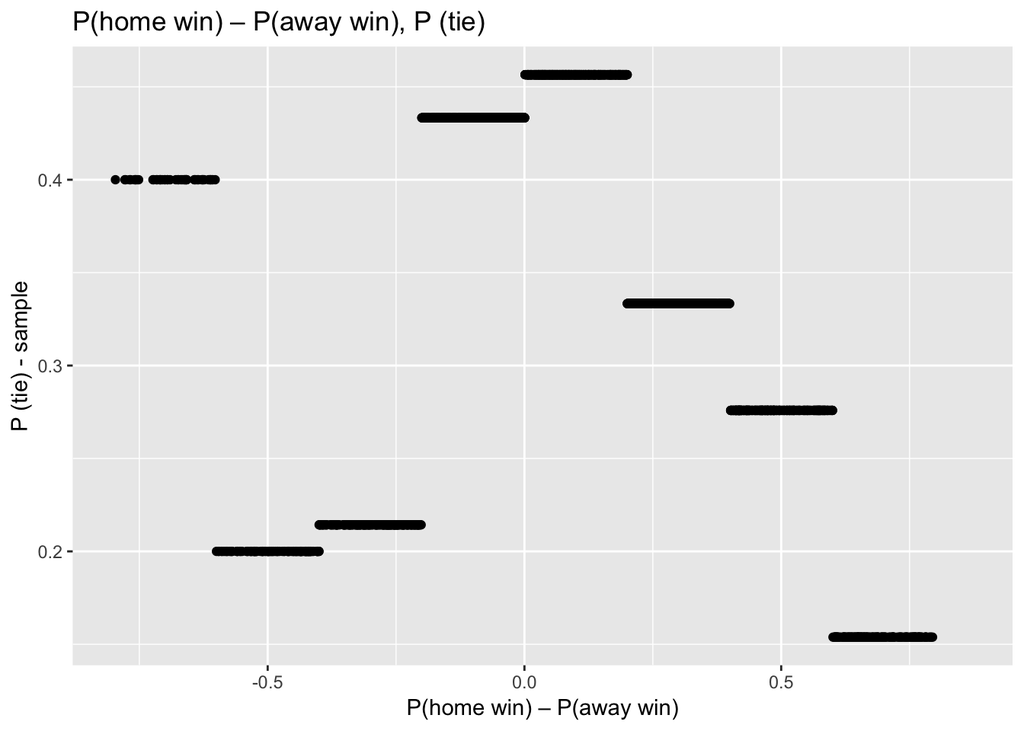

```r
  filter(graph, odd_bookmakers=="Betclic") %>%
  ggplot()+aes(x=p12,y=prob)+geom_point()+xlab("P(home win) – P(away win)")+ylab("P (tie) - sample")+ggtitle("P(home win) – P(away win), P (tie)")
```

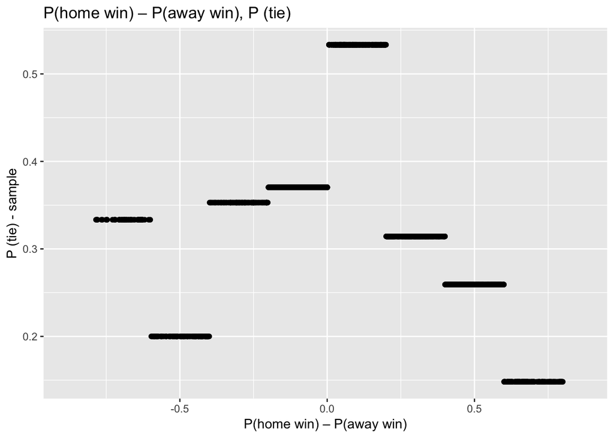

```r
  filter(graph, odd_bookmakers=="NordicBet") %>%
  ggplot()+aes(x=p12,y=prob)+geom_point()+xlab("P(home win) – P(away win)")+ylab("P (tie) - sample")+ggtitle("P(home win) – P(away win), P (tie)")
```